# S-Mobile: Predicting Customer Churn

### Question 2

#### Main Drivers of Churn Under the Logistic Regression (Standardized)

```r
## Logistic regression with standardization
result_logit_st <- logistic(
  s_mobile,
  rvar = "churn",
  evar = c(
    "changer", "changem", "revenue", "mou", "overage", "roam",
    "conference", "months", "uniqsubs", "custcare", "retcalls",
    "dropvce", "eqpdays", "refurb", "smartphone", "highcreditr",
    "mcycle", "car", "travel", "region", "occupation"
  ),
  lev = "yes",
  wts = "cweight",
  check = "standardize",
  data_filter = "training == 1"
)
summary(result_logit_st)
```

```
Logistic regression (GLM)
Data                 : s_mobile
Filter               : training == 1
Response variable    : churn
Level                : yes in churn
Explanatory variables: changer, changem, revenue, mou, overage, roam, conference, months, uniqsubs, custcare, retcalls, dropvce, eqpdays, refurb, smartphone, highcreditr, mcycle, car, travel, region, occupation
Weights used         : cweight
Null hyp.: there is no effect of x on churn
Alt. hyp.: there is an effect of x on churn
**Standardized odds-ratios and coefficients shown (2 X SD)**

                            OR coefficient std.error  z.value p.value
 (Intercept)                        -3.460     0.034 -102.843  < .001 ***
 changer                 1.066       0.064     0.019    3.393  < .001 ***
 changem                 0.865      -0.145     0.021   -7.089  < .001 ***
 revenue                 0.956      -0.045     0.029   -1.571   0.116
 mou                     0.680      -0.386     0.036  -10.830  < .001 ***
 overage                 1.786       0.580     0.023   25.712  < .001 ***
 roam                    1.097       0.093     0.014    6.720  < .001 ***
 conference              0.963      -0.038     0.024   -1.611   0.107
 months                  0.704      -0.350     0.023  -15.484  < .001 ***
 uniqsubs                1.066       0.064     0.017    3.799  < .001 ***
 custcare                0.975      -0.025     0.022   -1.138   0.255
 retcalls                1.244       0.218     0.012   17.784  < .001 ***
 dropvce                 1.138       0.129     0.023    5.632  < .001 ***
 eqpdays                 1.827       0.603     0.022   27.211  < .001 ***
 refurb|yes              1.318       0.276     0.025   11.013  < .001 ***
 smartphone|yes          0.913      -0.091     0.030   -3.049   0.002 **
 highcreditr|yes         0.483      -0.727     0.031  -23.702  < .001 ***
 mcycle|yes              0.883      -0.125     0.029   -4.330  < .001 ***
 car|yes                 0.991      -0.009     0.038   -0.241   0.810
 travel|yes              0.781      -0.247     0.039   -6.277  < .001 ***
 region|NE               0.644      -0.440     0.026  -16.633  < .001 ***
 region|NW               0.660      -0.416     0.026  -15.871  < .001 ***
 region|SE               0.650      -0.430     0.026  -16.425  < .001 ***
 region|SW               0.627      -0.467     0.026  -17.667  < .001 ***
 occupation|professional 1.416       0.348     0.022   15.974  < .001 ***
 occupation|student      1.900       0.642     0.030   21.048  < .001 ***
 occupation|retired      0.184      -1.690     0.054  -31.302  < .001 ***

Signif. codes:  0 '***' 0.001 '**' 0.01 '*' 0.05 '.' 0.1 ' ' 1

Pseudo R-squared: 0.047
Log-likelihood: -63796.27, AIC: 127646.541, BIC: 127955.245
Chi-squared: 6230.849 df(26), p.value < .001
Nr obs: 682,500
```

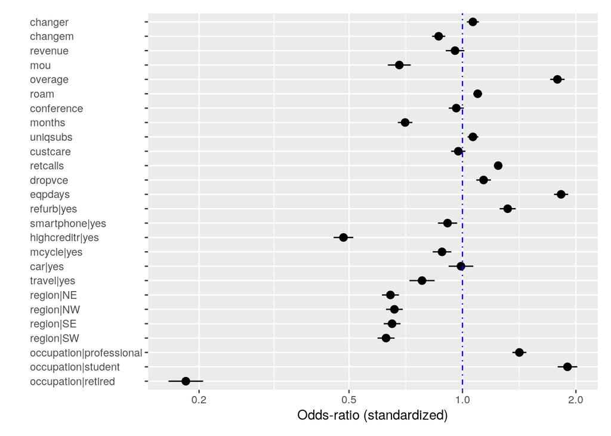

```r
## Look at the plot of relative importance of explanatory variables
plot(result_logit_st, custom = FALSE)
```

```r
## Print the ranking of relative importance of explanatory variables
rank_logit_st <- write.coeff(result_logit_st, sort = TRUE)
```

```
Standardized coefficients selected
```

```r
rank_logit_st
```

```
                     label        OR  coefficient  std.error      z.value       p.value sig_star dummy         mean          sd min  max importance
1              (Intercept) 0.0000000 -3.460310661 0.03364641 -102.8433968  0.000000e+00      ***     0   1.00000000   0.0000000   1    1   0.000000
2       occupation|retired 0.1844451 -1.690403332 0.05400355  -31.3017064 4.423369e-215      ***     1   0.08322344   0.2762247   0    1   5.421667
3          highcreditr|yes 0.4832916 -0.727135109 0.03067855  -23.7017423 3.459573e-124      ***     1   0.13688645   0.3437337   0    1   2.069144
4       occupation|student 1.8996946  0.641693114 0.03048771   21.0476029  2.405416e-98      ***     1   0.07615385   0.2652490   0    1   1.899695
5                  eqpdays 1.8268261  0.602580075 0.02214507   27.2105689 4.870019e-163      ***     0 355.69131868 232.3331895   0 1799   1.826826
6                  overage 1.7862790  0.580134704 0.02256256   25.7122726 8.522202e-146      ***     0  66.27428571  69.2580678   0  283   1.786279
7                region|SW 0.6268983 -0.466970884 0.02643243  -17.6665894  7.584599e-70      ***     1   0.18996337   0.3922791   0    1   1.595155
8                region|NE 0.6439513 -0.440132181 0.02646111  -16.6331729  4.007964e-62      ***     1   0.18827839   0.3909415   0    1   1.552912
9                region|SE 0.6504307 -0.430120480 0.02618765  -16.4245526  1.276215e-60      ***     1   0.19142857   0.3934328   0    1   1.537443
10               region|NW 0.6597485 -0.415896649 0.02620540  -15.8706450  1.011955e-56      ***     1   0.19124542   0.3932890   0    1   1.515729
11                     mou 0.6797758 -0.385992209 0.03564079  -10.8300700  2.479658e-27      ***     0 515.32230769 525.4589251   0 7668   1.471073
12                  months 0.7043384 -0.350496313 0.02263576  -15.4841827  4.436652e-54      ***     0  18.78150183   9.5956143   6   61   1.419772
13 occupation|professional 1.4157184  0.347637092 0.02176270   15.9739845  1.939878e-57      ***     1   0.21208791   0.4087943   0    1   1.415718
14              refurb|yes 1.3181590  0.276236084 0.02508286   11.0129440  3.310075e-28      ***     1   0.14362637   0.3507169   0    1   1.318159
15              travel|yes 0.7811545 -0.246982302 0.03934817   -6.2768441  3.455141e-10      ***     1   0.05578755   0.2295152   0    1   1.280156
16                retcalls 1.2437997  0.218170995 0.01226760   17.7843263  9.348019e-71      ***     0   0.04252747   0.2221832   0    4   1.243800
17                 changem 0.8646078 -0.145479312 0.02052063   -7.0894184  1.346767e-12      ***     0  15.21139194  51.8855768 -78  521   1.156594
18                 dropvce 1.1376704  0.128982657 0.02290106    5.6321709  1.779552e-08      ***     0   2.94633700   4.4043010   0   67   1.137670
19              mcycle|yes 0.8825334 -0.124958640 0.02886069   -4.3297183  1.493002e-05      ***     1   0.18820513   0.3908830   0    1   1.133102
20                    roam 1.0974724  0.093009684 0.01384153    6.7196120  1.822091e-11      ***     0   1.19725275   7.2543265   0  692   1.097472
21          smartphone|yes 0.9128406 -0.091193965 0.02990853   -3.0490957  2.295313e-03      **      1   0.89692308   0.3040649   0    1   1.095481
22                uniqsubs 1.0659099  0.063828758 0.01680254    3.7987575  1.454233e-04      ***     0   1.54622711   0.8910515   1   18   1.065910
23                 changer 1.0656822  0.063615170 0.01874907    3.3929776  6.913729e-04      ***     0   8.66124542  28.9568225 -62  305   1.065682
24                 revenue 0.9555596 -0.045458099 0.02893239   -1.5711835  1.161400e-01              0  57.21113553  43.2589496   0  856   1.046507
25              conference 0.9626874 -0.038026562 0.02361023   -1.6105966  1.072677e-01              0   0.26347985   1.0838975   0   56   1.038759
26                custcare 0.9748725 -0.025448549 0.02235432   -1.1384177  2.549461e-01              0   2.28813187   4.1929696   0   32   1.025775
27                 car|yes 0.9907814 -0.009261309 0.03846373   -0.2407803  8.097254e-01              1   0.09205128   0.2891036   0    1   1.009304
```

```r
## Report the top 10 main drivers of churn and their relative importance under the logistic regression (We can refer OR for positive or negative effects of each explanatory variable on the response variable (churn))
top10_driver_logit <- rank_logit_st[c('label', 'OR','importance')][2:11, ]
top10_driver_logit
```

```
                label        OR importance
2  occupation|retired 0.1844451   5.421667
3     highcreditr|yes 0.4832916   2.069144
4  occupation|student 1.8996946   1.899695
5             eqpdays 1.8268261   1.826826
6             overage 1.7862790   1.786279
7           region|SW 0.6268983   1.595155
8           region|NE 0.6439513   1.552912
9           region|SE 0.6504307   1.537443
10          region|NW 0.6597485   1.515729
11                mou 0.6797758   1.471073
```

#### Main Drivers of Churn Under the Neural Network

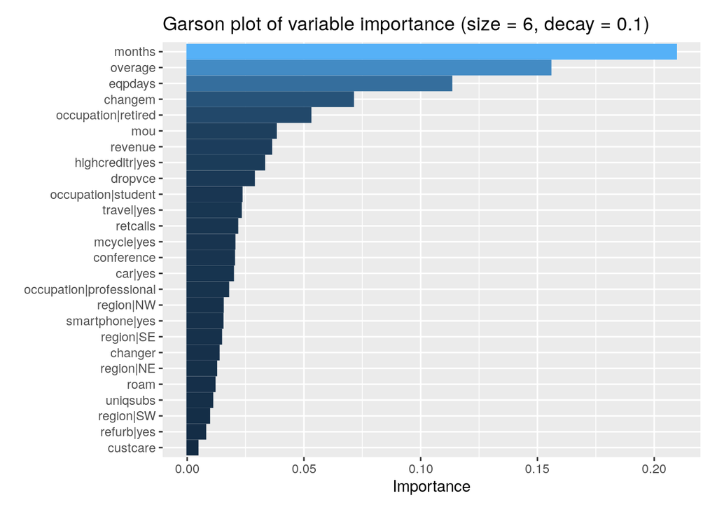

```r
## Look at the plot of variable importance of explanatory variables
plot(result_nn_cv, plots = "garson", custom = FALSE)
```

[figure not shown]

```r
## Look at the plots of partial dependence of explanatory variables
pd_nn <- plot(result_nn_cv, plots = "pdp", custom = FALSE)
```

[figure not shown]

```r
pd_nn
```

### Question 3 - Look at the report

### Question 4

#### Months

```r
## Explore the statistics of months in the representative set
result <- explore(
  s_mobile,
  vars = "months",
  fun = c("n_obs", "mean", "min", "max", "sd", "median"),
  data_filter = "representative==1",
  nr = Inf
)
#summary(result)
dtab(result) %>% render()
```

[interactive table not shown]

```r
## Try median value of months for comparison
pred <- predict(result_nn_cv, pred_data = s_mobile, pred_cmd = "months = 16")
s_mobile <- store(s_mobile, pred, name = "p_months16")
result <- explore(
  s_mobile,
  vars = c("churn", "p_months16"),
  fun = c("n_obs", "mean"),
  data_filter = "representative == 1 & months < 16",
  nr = Inf
)
dtab(result, dec = 4) %>% render()
```

[interactive table not shown]

#### Comment: These two average churn rates are very close.

```r
## Try 15 months to check whether the actual churn rate is lower than the predicted churn rate under the action
pred <- predict(result_nn_cv, pred_data = s_mobile, pred_cmd = "months = 15")
s_mobile <- store(s_mobile, pred, name = "p_months15")
result <- explore(
  s_mobile,
  vars = c("churn", "p_months15"),
  fun = c("n_obs", "mean"),
  data_filter = "representative == 1 & months < 15",
  nr = Inf
)
dtab(result, dec = 4) %>% render()
```

[interactive table not shown]

#### Comment: The actual churn rate is lower than the predicted churn rate under the action, so we decide that we need 16+ months to lower our churn rate.

```r
## We assume the months variable to be 24 (2 year) as our incentive
pred <- predict(result_nn_cv, pred_data = s_mobile, pred_cmd = "months = 24")
s_mobile <- store(s_mobile, pred, name = "p_months24")
result <- explore(
  s_mobile,
  vars = c("churn", "p_months24"),
  fun = c("n_obs", "mean"),
  data_filter = "representative == 1 & months < 24",
  nr = Inf
)
dtab(result, dec = 4) %>% render()
```

[interactive table not shown]

#### Comment: The churn rate decreased from 0.0205 to 0.0170.

#### Overage

```r
## Explore the statistics of overage in the representative set
result <- explore(
  s_mobile,
  vars = "overage",
  fun = c("n_obs", "mean", "min", "max", "sd", "median"),
  data_filter = "representative==1",
  nr = Inf
)
#summary(result)
dtab(result) %>% render()
```

[interactive table not shown]

```r
## We assume the overage variable to be 0 (ideal) as our incentive
pred <- predict(result_nn_cv, pred_data = s_mobile, pred_cmd = "overage = 0")
s_mobile <- store(s_mobile, pred, name = "p_overage0")
result <- explore(
  s_mobile,
  vars = c("churn", "p_overage0"),
  fun = c("n_obs", "mean"),
  data_filter = "representative == 1 & overage > 0",
  nr = Inf
)
dtab(result, dec = 4) %>% render()
```

[interactive table not shown]

#### Comment: The churn rate decreased from 0.0243 to 0.0162.

#### Eqpdays

```r
## Explore the statistics of eqpdays in the representative set
result <- explore(
  s_mobile,
  vars = "eqpdays",
  fun = c("n_obs", "mean", "min", "max", "sd", "median"),
  data_filter = "representative==1",
  nr = Inf
)
#summary(result)
dtab(result) %>% render()
```

[interactive table not shown]

```r
## We assume the eqpdays variable to be 279 (median) as our incentive
pred <- predict(result_nn_cv, pred_data = s_mobile, pred_cmd = "eqpdays = 279")
s_mobile <- store(s_mobile, pred, name = "p_eqpdays279")
result <- explore(
  s_mobile,
  vars = c("churn", "p_eqpdays279"),
  fun = c("n_obs", "mean"),
  data_filter = "representative == 1 & eqpdays > 279",
  nr = Inf
)
dtab(result, dec = 4) %>% render()
```

[interactive table not shown]

#### Comment: The churn rate decreased from 0.0265 to 0.0188.

### Question 6

#### Assumption 1: Monthly revenue is assumed to be the same as the average revenue in the representative set.

#### Assumption 2: Assume the cost is 0 (i.e. profitability is based on revenue).

#### Assumption 3: Assume the monthly discount rate to be 0.8%.

#### Assumption 4: Optimistic discounting - Customers pay at the beginning of each month.

```r
## Get monthly revenue, discount rate, and the list of discount number
mon_rev <- mean(representative$revenue)
mon_rev_list <- rep(mon_rev, 60)
disc_rate <- 0.008
disc_num <- seq(0, 59, 1)
```

```r
## Write the function for calculating the total CLV of 60 months
clv <- function(rev, churn, disc_nr, disc) {
  retention <- c(1, cumprod(1 - churn)[1:length(cumprod(1 - churn)) - 1])
  exp_prof <- rev * retention
  PV_exp_prof <- exp_prof / (1 + disc)^disc_nr
  CLV <- cumsum(PV_exp_prof)
  return(tail(CLV, 1))
}
```

#### Months

##### No action

```r
## Get the total CLV if we take no action for variable months
churn_rate <- rep(0.0205, 60)

months_no_action <- clv(rev = mon_rev_list, churn = churn_rate, disc_nr = disc_num, disc = disc_rate)
months_no_action
```

```
[1] 1644.712
```

##### Take action (24 months)

```r
## Get the total CLV if we take action for variable months
churn_rate24 <- rep(0.017, 60)

months24 <- clv(rev = mon_rev_list, churn = churn_rate24, disc_nr = disc_num, disc = disc_rate)
months24
```

```
[1] 1777.477
```

##### Profitability implication for variable months

```r
## Get the difference of CLVs under no action and taking action for variable months
months_prof <- months24 - months_no_action
months_prof
```

```
[1] 132.7654
```

#### Overage

##### No action

```r
## Get the total CLV if we take no action for variable overage
churn_rate_overage <- rep(0.0243, 60)

overage_no_action <- clv(rev = mon_rev_list, churn = churn_rate_overage, disc_nr = disc_num, disc = disc_rate)
overage_no_action
```

```
[1] 1516.996
```

##### Take action (overage = 0)

```r
## Get the total CLV if we take action for variable overage
churn_rate_overage0 <- rep(0.0162, 60)

overage0 <- clv(rev = mon_rev_list, churn = churn_rate_overage0, disc_nr = disc_num, disc = disc_rate)
overage0
```

```
[1] 1810.087
```

##### Profitability implication for variable overage

```r
## Get the difference of CLVs under no action and taking action for variable overage
overage_prof <- overage0 - overage_no_action
overage_prof
```

```
[1] 293.0917
```

#### Eqpdays

##### No action

```r
## Get the total CLV if we take no action for variable eqpdays
churn_rate_eqpdays <- rep(0.0265, 60)

eqpdays_no_action <- clv(rev = mon_rev_list, churn = churn_rate_eqpdays, disc_nr = disc_num, disc = disc_rate)
eqpdays_no_action
```

```
[1] 1449.959
```

##### Take action (eqpdays = 279)

```r
## Get the total CLV if we take action for variable eqpdays
churn_rate_eqpdays279 <- rep(0.0188, 60)

eqpdays279 <- clv(rev = mon_rev_list, churn = churn_rate_eqpdays279, disc_nr = disc_num, disc = disc_rate)
eqpdays279
```

```
[1] 1707.253
```

```r
## Get the difference of CLVs under no action and taking action for variable eqpdays
eqpdays_prof <- eqpdays279 - eqpdays_no_action
eqpdays_prof
```

```
[1] 257.2939
```

#### Compare three actions

```r
## Create the tibble
action_tibble <- tibble::tibble(
  Variable = c("Months", "Overage", "Eqpdays"),
  NoActionCLV = c(1644.712, 1516.996, 1449.959),
  TakeActionCLV = c(1777.477, 1810.087, 1707.253),
  ProfitabilityImplication = c(132.7654, 293.0917, 257.2939)) %>%
  mutate(Variable = factor(Variable, levels = Variable))
arrange(action_tibble, desc(ProfitabilityImplication))
```

```
# A tibble: 3 x 4
  Variable NoActionCLV TakeActionCLV ProfitabilityImplication
  <fct>          <dbl>         <dbl>                    <dbl>
1 Overage        1517.         1810.                     293.
2 Eqpdays        1450.         1707.                     257.
3 Months         1645.         1777.                     133.
```

## Report

### Step 2 - Main Drivers and Relative Importance

#### Based on the logistic regression model, the top 10 drivers are occupation|retired (negative effect on churn since OR = 0.18 < 1), highcreditr|yes (negative effect on churn since OR = 0.48 < 1), occupation|student (positive effect on churn since OR = 1.90 > 1), eqpdays (positive effect on churn since OR = 1.83 > 1), overage (positive effect on churn since OR = 1.79 > 1), region|SW (negative effect on churn since OR = 0.63 < 1), region|NE (negative effect on churn since OR = 0.64 < 1), region|SE (negative effect on churn since OR = 0.65 < 1), region|NW (negative effect on churn since OR = 0.66 < 1), mou (negative effect on churn since OR = 0.68 < 1).

#### Based on the neural network model, the top 10 drivers are months (negative effect based on its partial dependence plot), overage (positive effect based on its partial dependence plot), eqpdays (positive effect based on its partial dependence plot), changem (positive effect based on its partial dependence plot), occupation|retired (occupation = retired leads to lower churn based on its partial dependence plot), mou (negative effect based on its partial dependence plot), revenue (positive effect based on its partial dependence plot), highcreditr|yes (highcredit = yes leads to lower churn based on its partial dependence plot), dropvce (positive effect based on its partial dependence plot), occupation|student (occupation = student leads to higher churn based on its partial dependence plot).

### Step 3 - Action Development

#### Months (# of months the customer has had service): According to the partial dependence plot, the longer the customer has had the service, the less likely that the customer will churn. Action 1: If a long-term customer decides to churn, we can offer more discounts compared to a short-term customer. Action 2: We can develop some promotional strategies to attract customers to sign long-term contracts.

#### Overage (Mean monthly overage minutes): According to the partial dependence plot, the more overage minutes the customer has, the more likely that the customer will churn. In addition, there is a certain range that the customer’s churn rate increases dramatically. Action 1: Lower the overage cost. Action 2: Offer more bundles/packages with more flexibility for customers to choose from. Action 3: Use the customer’s past data to predict in advance whether the customer would have overage cost. Send notifications to customers who are very likely to have overage cost to change to a better plan.

#### Eqpdays (Number of days customer has owned current handset): According to the partial dependence plot, the longer the customer has owned the current handset, the more likely the customer will churn. Action 1: Encourage customers to upgrade to newer equipment, offer them upgrade discounts. Action 2:Predict when the equipment needs to be changed, and send notifications to customers / offer cheap replacement.

#### Changem (% change in minutes of use over the most recent 4 month period): According to the partial dependence plot, a customer with higher % change in minutes of use over the most recent 4 month period is more likely to churn. Action: Similar to solving overage, offer more flexible plans, and make it easier for customers to switch between.

#### Occupation (Categorical variable with 4 occupation levels): According to the partial dependence plot, the retired customers are the least likely to churn, while the students are the most likely to churn. There is nothing we can do about it at the retention stage (we may target more retired customers at the acquisition stage).

### Step 4 - Action Quantification

#### Months: Assume the months variable to be 24 (2 years) as our incentive. Reason: The median value of months in the representative set is 16 and the mean value is 18. We first tried months = 16, and found that the churn rate of taking action is very similar to the churn rate under no action. We then tried months = 15, and found that the churn rate under no action is lower than that under taking action. We decided to take a value that is larger than 16 so that we can reduce the churn rate. In this case, months = 24 makes more sense in reality. The churn rate decreased from 0.0205 to 0.0170. For test, we attract customers to sign long-term contracts and offer more when long-term customers decide to churn to see if the average length increased.

#### Overage: Assume the overage variable to be 0 (ideal) as our incentive. Reason: Since we want to recommend different plans to our customers to make sure that most of them don’t have overage cost, we set overage = 0 as our result after taking action. The churn rate decreased from 0.0243 to 0.0162. For test, we lower overage costs and offer more plans so that we can try to cover usage needs for all range of customers. Ideally, the overage should be zero.

#### Eqpdays: Assume the eqpdays variable to be 279 (median) as our incentive. The churn rate decreased from 0.0265 to 0.0188. We encourage customers to upgrade to newer equipment, and offer them upgrade discounts to shorten the eqpdays to the current median.

### Step 5 - Action Target

#### Months - Action: Increase the number of months to at least 24 months. Targeting rule: Customers who have months < 24. Expected churn benefit: Baseline churn: 0.0205; projected churn: 0.0170.

#### Overage (Mean monthly overage minutes) - Action: Eliminate overage minutes. Targeting rule: Customers who have overage > 0. Expected churn benefit: Baseline churn: 0.0243; projected churn: 0.0162.

#### Eqpdays - Action: Change equipment for customers who have eqpdays > 279, which is the medium eqpdays in the representative dataset. Targeting rule: Customers who have eqpdays > 279. Expected churn benefit: Baseline churn: 0.0265; projected churn: 0.0188.

#### Changem - Action: Offer more flexible plans, and make it easier for customers to switch between. Targeting rule: All customers. Expected churn benefit: N/A since we can’t come up with a realistic action to deal with this driver.

#### Occupation|retired - Action: Target more retired customers. Targeting rule: Retired people at the acquisition stage. Expected churn benefit: N/A since we can’t deal with this driver at the retention stage.

### Step 6 - Economics Evaluation

#### Assumptions: (1) Monthly revenue is assumed to be the same as the average revenue in the representative set, which is 56.63 SGD. (2) Assume the cost is 0 (i.e. profitability is based on revenue). (3) Assume the monthly discount rate to be 0.8%. (4) Assume optimistic discounting - customers pay at the beginning of each month.

#### Results: Based on the churn rates in question 4, we got that the implied profitability is the highest for taking action on the overage driver (overage = 293.0917 > eqpdays = 257.2939 > months = 132.7654).